# Smart buildings

9 November 2017

## Overview

- Smart buildings
- Analysing the data
- Building an end product

## Smart buildings

### Trying to be smart with commercial building data

## How do commercial buildings work?

- Facility managers (FMs) oversee the day to day operations of a commercial building.
- Used to be a whole team!
- Shrinking maintenance budgets and increasing complexity makes this a challenging problem.
- Building operations are automated by Building Management Systems (BMSs).

## What is a BMS?

- Commercial buildings contain Building Management Systems (BMSs) to improve indoor environment quality and reduce energy consumption.
- A BMS will control heating, cooling, ventilation and lighting systems.
- Contain thousands of points for sensors (temperature, humidity), actuators (fans, motors, dampers) and software (schedule, trend logs, calculations).
- A BMS will monitor sensors and adjust actuators based on their readings.
- For example, if high temperatures are recorded in a room, dampers will open and air handlers will modulate to provide cooler air.

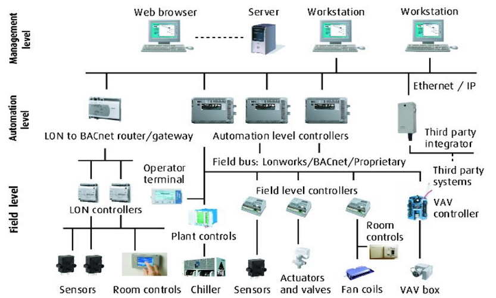

## How does this work in practice?

- Vendor sets up a BMS. The BMS will behave in a certain way based predefined rules.
- BMS systems are costly to implement and to modify. Can require a lot of coding to change the BMS's behaviour.
- The bigger the BMS is the harder it is to find what matters. Locating problems is difficult and time-consuming.
- For example, a heating valve might be locked open. If this isn't detected the BMS will cool the room to reach the required temperature.

## So what can we do?

- Help facility managers identify if a BMS is operating optimally.
  - Fault detection
  - Diagnostics
- Buildings Alive's goal is to
  - Collect BMS data using our E2 device
  - Analyse and transform data into useful information.
  - Help guide FM's to find out what's wrong.
  - Provide timely and actionable information.

## Analysing the data

### Feature generation, dimensionality reduction, clustering

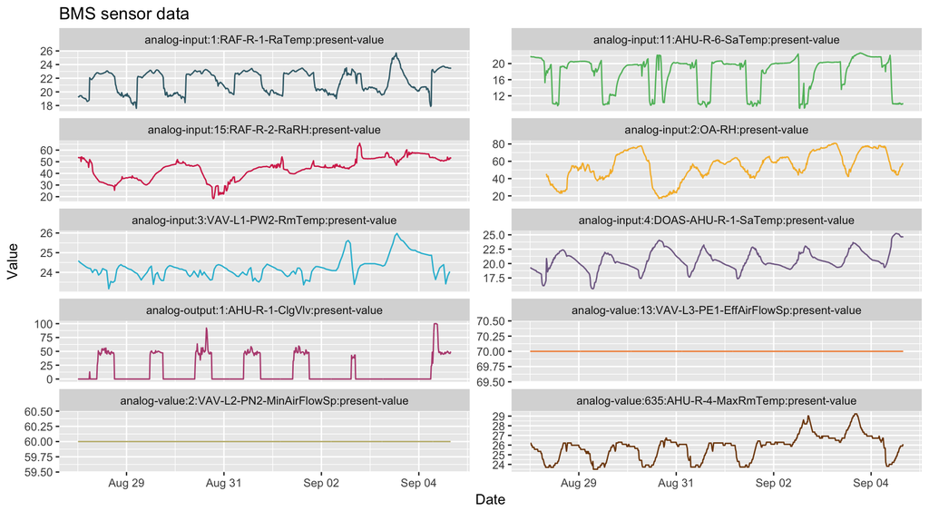

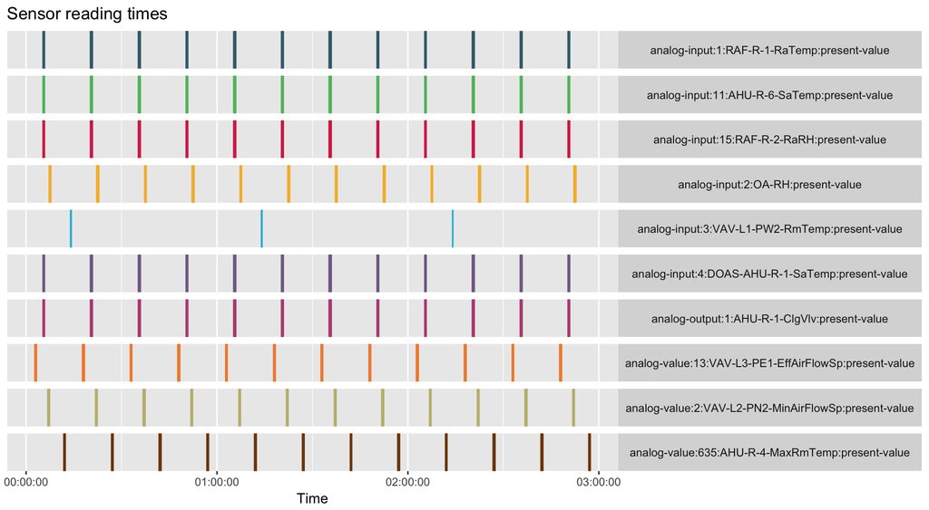

## Feature generation

- Dealing with thousands of unevenly spaced time-series.
- Uneven spacing in time-series presents difficulties.
- Rather than rounding or imputing data we can generate features and work with them instead.

## What features might be useful?

Feature generation for time-series clustering is discussed in Wang, Smith, and Hyndman (2006). Some useful features for our case might be

- Mean
- Standard deviation
- Kurtosis
- Skewness
- Biggest change (\(\max_i \left\{ \left| y_{t_i} - y_{t_{i-1}} \right| \right\}\))
- Smallest change (\(\min_i \left\{ \left| y_{t_i} - y_{t_{i-1}} \right| \right\}\))
- Number of "mean crossings" per day

Normalise these features using their median, \(M\), and interquartile range, \(IQR\),

\[ y^* = \frac{y - M}{IQR}. \]

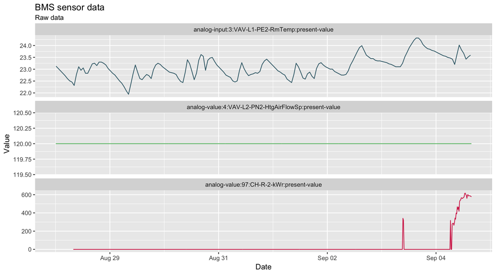

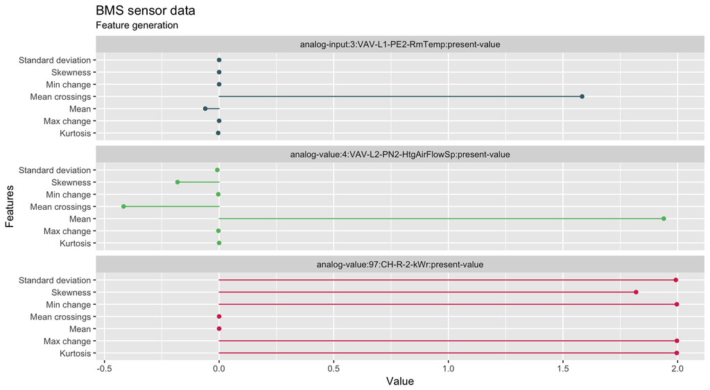

## Dimension reduction and clustering

- Too many sensors to visualise easily.
- Use dimensionality reduction.
- Identify clusters and singletons.

### Which clustering algorithm?

| Method | Advantages | Disadvantages |
| --- | --- | --- |
| K-means | Easy to learn. | Outperformed by other algorithms. |
| Hierarchical clustering | Informative - produces a dendrogram. | Not suitable for large data sets - \(\mathcal{O}(n^2 \log(n))\) time complexity. |
| Affinity propagation | Automatically determines number of clusters. | Not suitable for large data sets - \(\mathcal{O}(n^2 t)\) time complexity. |
| Spectral clustering | Good performance. | See Nadler and Galun (2007). Time complexity of \(\mathcal{O}(n^3)\). |

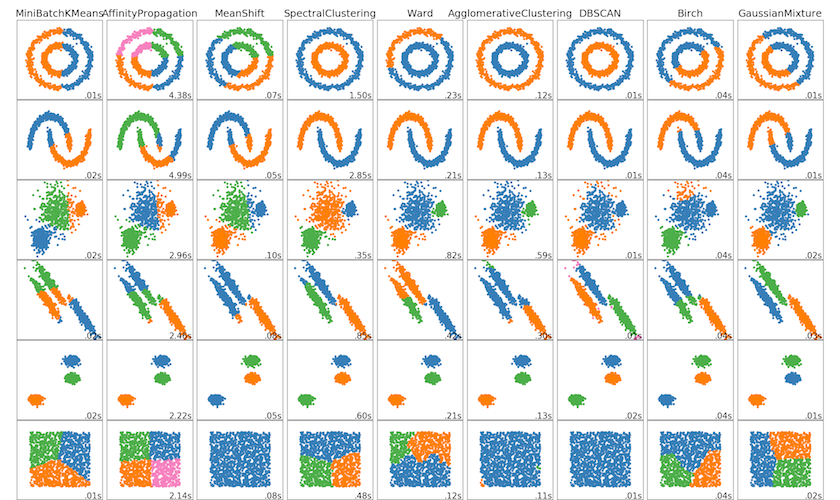

Image: (“Comparing Different Clustering Algorithms on Toy Datasets” 2017)

## Obligatory mathematics slide

### Spectral clustering

We are given \(n\) points \(x_i \in \mathbb{R}^p\) and a similarity matrix \(\mathbf{S}\). Define the weight matrix, degree matrix and graph Laplacian as

\[ \begin{split} \mathbf{W} &= \left(w_{ij}\right) \in \mathbb{R}^{n \times n} \\ \mathbf{D} &= \mathrm{diag} \left( d_i \right) \\ \mathbf{L} &= \mathbf{D} - \mathbf{W}, \end{split} \]

where,

- \(w_{ij}\) is the weight between nodes \(i\) and \(j\) based on \(\mathbf{S}\), and,
- \(d_i = \sum_{j=1}^n w_{ij}\) is the weighted degree of node \(i\).

Once \(\mathbf{L}\) is determined find the \(m\) eigenvectors \(\mathbf{Z}_{n \times m}\) corresponding to the \(m\) smallest eigenvalues of \(\mathbf{L}\). Finally, cluster the rows of \(\mathbf{Z}_{n \times m}\) using K-means.

## Building a prototype

### Prototyping with Dash

## Dash

- Recently released by Plotly.
- Easily build web applications for data analytics.
- Open sourced under the MIT license.
- Works nicely with the existing Plotly graphing libraries.
- Python equivalent of `R`'s Shiny.

[figure not shown]

[figure not shown]

## Simple example

```python
import dash
from dash.dependencies import Input, Output
import dash_core_components as dcc
import dash_html_components as html
import pandas as pd

app = dash.Dash()

app.layout = html.Div([
    dcc.Dropdown(id='my-dropdown',
                 options=[{'label': 'Option A', 'value': 'A'},
                          {'label': 'Option B', 'value': 'B'}]),
    dcc.Graph(id='my-graph')
])

@app.callback(Output('my-graph', 'figure'),
              [Input('my-dropdown', 'value')])
def update_graph(dd_value):
    df_query = df.query("Variable == @dd_value")
    return {'data': [{'x': df_query.x, 'y': df_query.y}]}

if __name__ == '__main__':
    app.run_server()
```

## Demonstration

## Thank you for listening!

### Any questions?

## References

“Comparing Different Clustering Algorithms on Toy Datasets.” 2017. http://scikit-learn.org/stable/auto_examples/cluster/plot_cluster_comparison.html.

Friedman, Jerome, Trevor Hastie, and Robert Tibshirani. 2001. *The Elements of Statistical Learning*. Vol. 1. Springer series in statistics New York.

Murphy, Kevin P. 2012. *Machine Learning: A Probabilistic Perspective*. MIT Press.

Nadler, Boaz, and Meirav Galun. 2007. “Fundamental Limitations of Spectral Clustering.” In *Advances in Neural Information Processing Systems 19*, edited by P B Schölkopf, J C Platt, and T Hoffman, 1017–24. MIT Press.

Von Luxburg, Ulrike. 2007. “A Tutorial on Spectral Clustering.” *Statistics and Computing*.

Wang, Xiaozhe, Kate Smith, and Rob Hyndman. 2006. “Characteristic-Based Clustering for Time Series Data.” *Data Mining and Knowledge Discovery* 13 (3): 335–64.